# Exercise 1 solutions: Detection function analysis

David L Miller

# Aims

By the end of this exercise you should feel confident doing the following:

- Loading data from ArcGIS `.gdb` files
- Working on a `data.frame` in R to get it into the correct format for `Distance`
- Fitting a detection function using `ds()`
- Checking detection functions
- Making at goodness of fit plots
- Selecting models using AIC
- Estimating abundance using `dht()`

# Preamble

First need to load the requisite R libraries

```r
library(rgdal)
```

```r
library(ggplot2)
library(Distance)
library(knitr)
```

# Load the data

The observations are located in a “geodatabase” we created in Arc. We want to pull out the “Sightings” table (called a “layer”) and make it into a `data.frame` (so that it’s easier for R to manipulate).

```r
distdata <- readOGR("Analysis.gdb", layer="Sightings")
```

```
## NOTE: rgdal::checkCRSArgs: no proj_defs.dat in PROJ.4 shared files
```

```r
distdata <- as.data.frame(distdata)
```

We can check it has the correct format using `head`:

```r
head(distdata)
```

```
##    Survey GroupSize SeaState  Distance        SightingTime SegmentID
## 1 en04395         2      3.0  246.0173 2004/06/28 10:22:21        48
## 2 en04395         2      2.5 1632.3934 2004/06/28 13:18:14        50
## 3 en04395         1      3.0 2368.9941 2004/06/28 14:13:34        51
## 4 en04395         1      3.5  244.6977 2004/06/28 15:06:01        52
## 5 en04395         1      4.0 2081.3468 2004/06/29 10:48:31        56
## 6 en04395         1      2.4 1149.2632 2004/06/29 14:35:34        59
##   SightingID coords.x1 coords.x2
## 1          1   -65.636    39.576
## 2          2   -65.648    39.746
## 3          3   -65.692    39.843
## 4          4   -65.717    39.967
## 5          5   -65.820    40.279
## 6          6   -65.938    40.612
```

The `Distance` package expects certain column names to be used. Renaming is much easier to do in R than ArcGIS, so we do it here.

```r
distdata$distance <- distdata$Distance
distdata$object <- distdata$SightingID
distdata$Sample.Label <- distdata$SegmentID
distdata$size <- distdata$GroupSize
```

Let’s see what we did:

```r
head(distdata)
```

```
##    Survey GroupSize SeaState  Distance        SightingTime SegmentID
## 1 en04395         2      3.0  246.0173 2004/06/28 10:22:21        48
## 2 en04395         2      2.5 1632.3934 2004/06/28 13:18:14        50
## 3 en04395         1      3.0 2368.9941 2004/06/28 14:13:34        51
## 4 en04395         1      3.5  244.6977 2004/06/28 15:06:01        52
## 5 en04395         1      4.0 2081.3468 2004/06/29 10:48:31        56
## 6 en04395         1      2.4 1149.2632 2004/06/29 14:35:34        59
##   SightingID coords.x1 coords.x2  distance object Sample.Label size
## 1          1   -65.636    39.576  246.0173      1           48    2
## 2          2   -65.648    39.746 1632.3934      2           50    2
## 3          3   -65.692    39.843 2368.9941      3           51    1
## 4          4   -65.717    39.967  244.6977      4           52    1
## 5          5   -65.820    40.279 2081.3468      5           56    1
## 6          6   -65.938    40.612 1149.2632      6           59    1
```

We now have four “extra” columns.

# Exploratory analysis

Before setting off fitting detection functions, let’s look at the relationship of various variables in the data.

*Don’t worry too much about understanding the code that generates these plots at the moment.*

## Distances

Obviously, the most important covariate in a distance sampling analysis is distance itself. We can plot a histogram of the distances to check that (1) we imported the data correctly and (2) it conforms to the usual shape for line transect data.

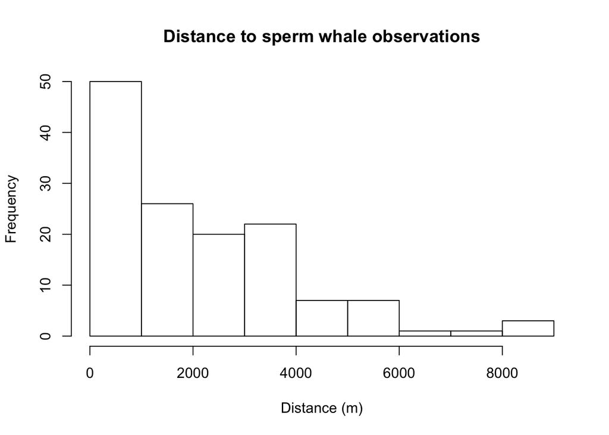

```r
hist(distdata$distance, xlab="Distance (m)", main="Distance to sperm whale observations")
```

## Size and distance

We might expect that there will be a relationship between the distance at whcih we see animals and the size of the groups observed (larger groups are easier to see at larger distances), so let’s plot that to help us visualise the relationship.

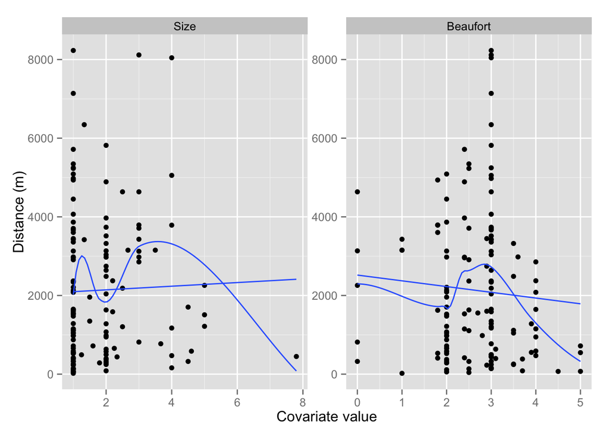

```r
# plot of size versus distance and sea state vs distance, linear model and LOESS smoother overlay

# put the data into a simple format, only selecting what we need
distplot <- distdata[,c("distance","size","SeaState")]
names(distplot) <- c("Distance", "Size", "Beaufort")
library(reshape2)
# "melt" the data to have only three columns (try head(distplot))
distplot <- melt(distplot, id.vars="Distance", value.name="covariate")

# make the plot
p <- ggplot(distplot, aes(x=covariate, y=Distance)) +
      geom_point() +
      facet_wrap(~variable, scale="free") +
      geom_smooth(method="loess", se=FALSE) +
      geom_smooth(method="lm", se=FALSE) +
      labs(x="Covariate value", y="Distance (m)")
print(p)
```

## Distance and sea state

```
## stat_bin: binwidth defaulted to range/30. Use 'binwidth = x' to adjust this.
## stat_bin: binwidth defaulted to range/30. Use 'binwidth = x' to adjust this.
## stat_bin: binwidth defaulted to range/30. Use 'binwidth = x' to adjust this.
## stat_bin: binwidth defaulted to range/30. Use 'binwidth = x' to adjust this.
## stat_bin: binwidth defaulted to range/30. Use 'binwidth = x' to adjust this.
```

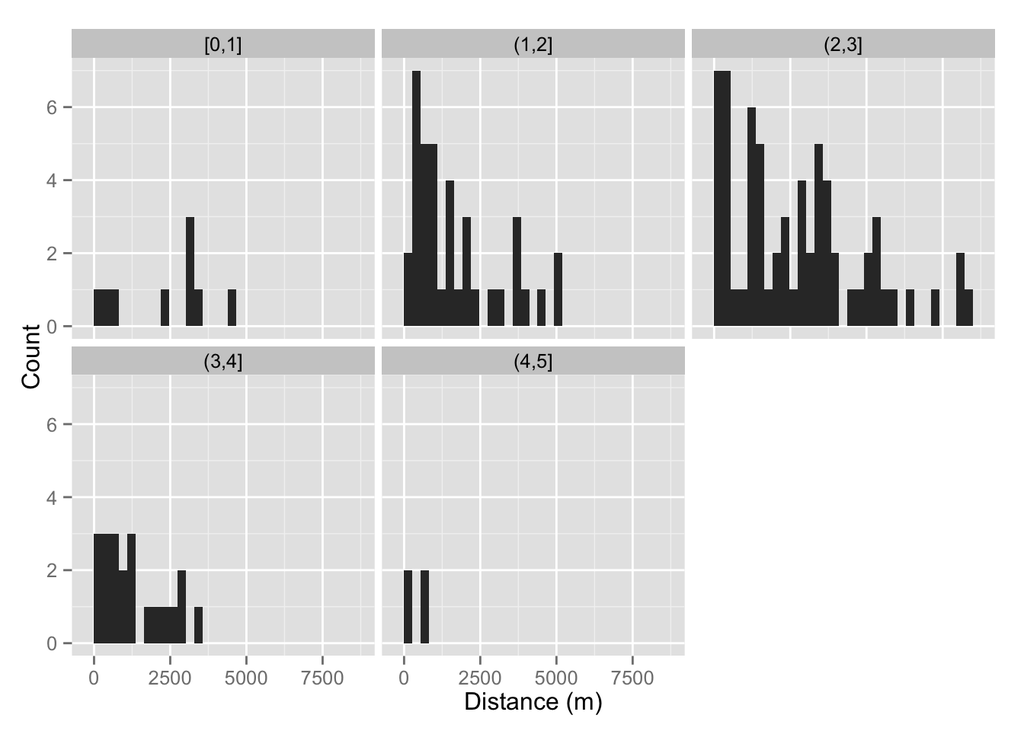

```r
distdata$SeaStateCut <- cut(distdata$SeaState,seq(0,5,by=1), include.lowest=TRUE)
p <- ggplot(distdata) +
      geom_histogram(aes(distance)) +
      facet_wrap(~SeaStateCut) +
      labs(x="Distance (m)", y="Count")
print(p)
```

## Survey effect

Given we are including data from two different surveys we can also investigate the relationship between survey and distances observed.

```
## stat_bin: binwidth defaulted to range/30. Use 'binwidth = x' to adjust this.
## stat_bin: binwidth defaulted to range/30. Use 'binwidth = x' to adjust this.
```

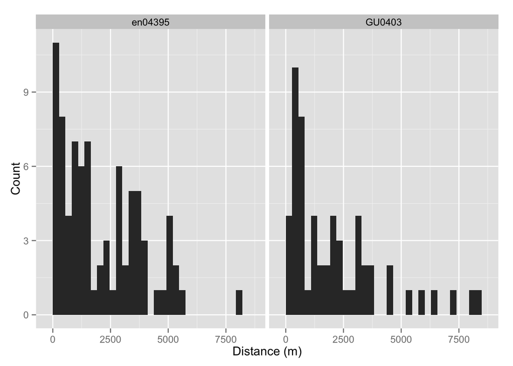

```r
p <- ggplot(distdata) +
      geom_histogram(aes(distance)) +
      facet_wrap(~Survey) +
      labs(x="Distance (m)", y="Count")
print(p)
```

# Fitting detection functions

Here we fit all possible detection function models with half-normal and hazard-rate functions using each combination of covariates. This is somewhat brute force.

We’ll store all the models in a list that we can then iterate over later.

```r
models <- list()

# half-normal models
models$hn <- ds(distdata, truncation=6000, adjustment=NULL)
```

```
## Fitting half-normal key function
## Key only models do not require monotonicity contraints. Not constraining model for monotonicity.
## AIC= 2252.06
## No survey area information supplied, only estimating detection function.
```

```r
models$hn.ss <- ds(distdata, truncation=6000, adjustment=NULL, formula=~SeaState)
```

```
## Fitting half-normal key function
## AIC= 2248.832
## No survey area information supplied, only estimating detection function.
```

```r
models$hn.size <- ds(distdata, truncation=6000, adjustment=NULL, formula=~size)
```

```
## Fitting half-normal key function
## AIC= 2253.892
## No survey area information supplied, only estimating detection function.
```

```r
models$hn.ss.size <- ds(distdata, truncation=6000, adjustment=NULL, formula=~size+SeaState)
```

```
## Fitting half-normal key function
## AIC= 2250.75
## No survey area information supplied, only estimating detection function.
```

```r
models$hn.survey <- ds(distdata, truncation=6000, adjustment=NULL, formula=~as.factor(Survey))
```

```
## Fitting half-normal key function
## AIC= 2252.35
## No survey area information supplied, only estimating detection function.
```

```r
models$hn.survey.ss <- ds(distdata, truncation=6000, adjustment=NULL, formula=~as.factor(Survey)+SeaState)
```

```
## Fitting half-normal key function
## AIC= 2250.441
## No survey area information supplied, only estimating detection function.
```

```r
models$hn.survey.size <- ds(distdata, truncation=6000, adjustment=NULL, formula=~as.factor(Survey)+size)
```

```
## Fitting half-normal key function
## AIC= 2254.339
## No survey area information supplied, only estimating detection function.
```

```r
models$hn.survey.size.ss <- ds(distdata, truncation=6000, adjustment=NULL, formula=~as.factor(Survey)+size+SeaState)
```

```
## Fitting half-normal key function
## AIC= 2252.378
## No survey area information supplied, only estimating detection function.
```

```r
# hazard-rate models
models$hr <- ds(distdata, truncation=6000, adjustment=NULL, key="hr")
```

```
## Fitting hazard-rate key function
## Key only models do not require monotonicity contraints. Not constraining model for monotonicity.
## AIC= 2247.594
## No survey area information supplied, only estimating detection function.
```

```r
models$hr.ss <- ds(distdata, truncation=6000, adjustment=NULL, formula=~SeaState, key="hr")
```

```
## Fitting hazard-rate key function
## AIC= 2247.347
## No survey area information supplied, only estimating detection function.
```

```r
models$hr.size <- ds(distdata, truncation=6000, adjustment=NULL, formula=~size, key="hr")
```

```
## Fitting hazard-rate key function
## AIC= 2249.427
## No survey area information supplied, only estimating detection function.
```

```r
models$hr.ss.size <- ds(distdata, truncation=6000, adjustment=NULL, formula=~size+SeaState, key="hr")
```

```
## Fitting hazard-rate key function
## AIC= 2249.327
## No survey area information supplied, only estimating detection function.
```

```r
models$hr.survey <- ds(distdata, truncation=6000, adjustment=NULL, formula=~as.factor(Survey), key="hr")
```

```
## Fitting hazard-rate key function
## AIC= 2248.871
## No survey area information supplied, only estimating detection function.
```

```r
models$hr.survey.ss <- ds(distdata, truncation=6000, adjustment=NULL, formula=~as.factor(Survey)+SeaState, key="hr")
```

```
## Fitting hazard-rate key function
## AIC= 2248.744
## No survey area information supplied, only estimating detection function.
```

```r
models$hr.survey.size <- ds(distdata, truncation=6000, adjustment=NULL, formula=~as.factor(Survey)+size, key="hr")
```

```
## Fitting hazard-rate key function
## AIC= 2250.146
## No survey area information supplied, only estimating detection function.
```

```r
models$hr.survey.size.ss <- ds(distdata, truncation=6000, adjustment=NULL, formula=~as.factor(Survey)+size+SeaState, key="hr")
```

```
## Fitting hazard-rate key function
## AIC= 2250.454
## No survey area information supplied, only estimating detection function.
```

# Model selection

This code will make a results table with relevant statistics for model selection in it.

```r
make_table <- function(models){

  # this function extracts the model data for a single model (row)
  extract_model_data <- function(model){
    c(summary(model)$ds$key,
      model$ddf$ds$aux$ddfobj$scale$formula,
      model$ddf$criterion,
      ddf.gof(model$ddf, qq=FALSE)$dsgof$CvM$p,
      summary(model)$ds$average.p,
      summary(model)$ds$average.p.se
    )
  }

  # applying that to all the models then putting it into a data.frame
  res <- as.data.frame(t(as.data.frame(lapply(models, extract_model_data))),
                        stringsAsFactors=FALSE)

  # making sure the correct columns are numeric
  res[,3] <- as.numeric(res[,3])
  res[,4] <- as.numeric(res[,4])
  res[,5] <- as.numeric(res[,5])
  res[,6] <- as.numeric(res[,6])

  # giving the columns names
  colnames(res) <- c("Key function", "Formula", "AIC", "Cramer-von Mises $p$-value",
                     "$\\hat{P_a}$", "se($\\hat{P_a}$)")

  # creating a new column for the AIC difference to the best model
  res[["$\\Delta$AIC"]] <- res$AIC - min(res$AIC, na.rm=TRUE)
  # ordering the model by AIC score
  res <- res[order(res$AIC),]

  # returning the data.frame
  return(res)
}
```

Here is the resulting table from the code above, made using the `kable` function from `knitr`:

```r
model_table <- make_table(models)
kable(model_table, digits=3)
```

|  | Key function | Formula | AIC | Cramer-von Mises $p$-value | $\hat{P_a}$ | se($\hat{P_a}$) | $\Delta$AIC |
| --- | --- | --- | --- | --- | --- | --- | --- |
| hr.ss | hr | ~SeaState | 2247.347 | 0.878 | 0.358 | 0.073 | 0.000 |
| hr | hr | ~1 | 2247.594 | 0.904 | 0.362 | 0.077 | 0.247 |
| hr.survey.ss | hr | ~as.factor(Survey) + SeaState | 2248.744 | 0.895 | 0.362 | 0.073 | 1.397 |
| hn.ss | hn | ~SeaState | 2248.832 | 0.070 | 0.542 | 0.040 | 1.485 |
| hr.survey | hr | ~as.factor(Survey) | 2248.871 | 0.875 | 0.377 | 0.076 | 1.524 |
| hr.ss.size | hr | ~size + SeaState | 2249.327 | 0.880 | 0.355 | 0.074 | 1.980 |
| hr.size | hr | ~size | 2249.427 | 0.899 | 0.355 | 0.077 | 2.079 |
| hr.survey.size | hr | ~as.factor(Survey) + size | 2250.146 | 0.859 | 0.365 | 0.076 | 2.799 |
| hn.survey.ss | hn | ~as.factor(Survey) + SeaState | 2250.441 | 0.101 | 0.538 | 0.038 | 3.094 |
| hr.survey.size.ss | hr | ~as.factor(Survey) + size + SeaState | 2250.454 | 0.844 | 0.352 | 0.075 | 3.107 |
| hn.ss.size | hn | ~size + SeaState | 2250.750 | 0.075 | 0.541 | 0.039 | 3.403 |
| hn | hn | ~1 | 2252.060 | 0.074 | 0.549 | 0.037 | 4.713 |
| hn.survey | hn | ~as.factor(Survey) | 2252.350 | 0.082 | 0.545 | 0.036 | 5.003 |
| hn.survey.size.ss | hn | ~as.factor(Survey) + size + SeaState | 2252.378 | 0.108 | 0.538 | 0.037 | 5.030 |
| hn.size | hn | ~size | 2253.892 | 0.076 | 0.549 | 0.037 | 6.544 |
| hn.survey.size | hn | ~as.factor(Survey) + size | 2254.339 | 0.082 | 0.545 | 0.037 | 6.992 |

The four best models are hr.ss, hr, hr.survey.ss, hn.ss

We can plot the best 4 models:

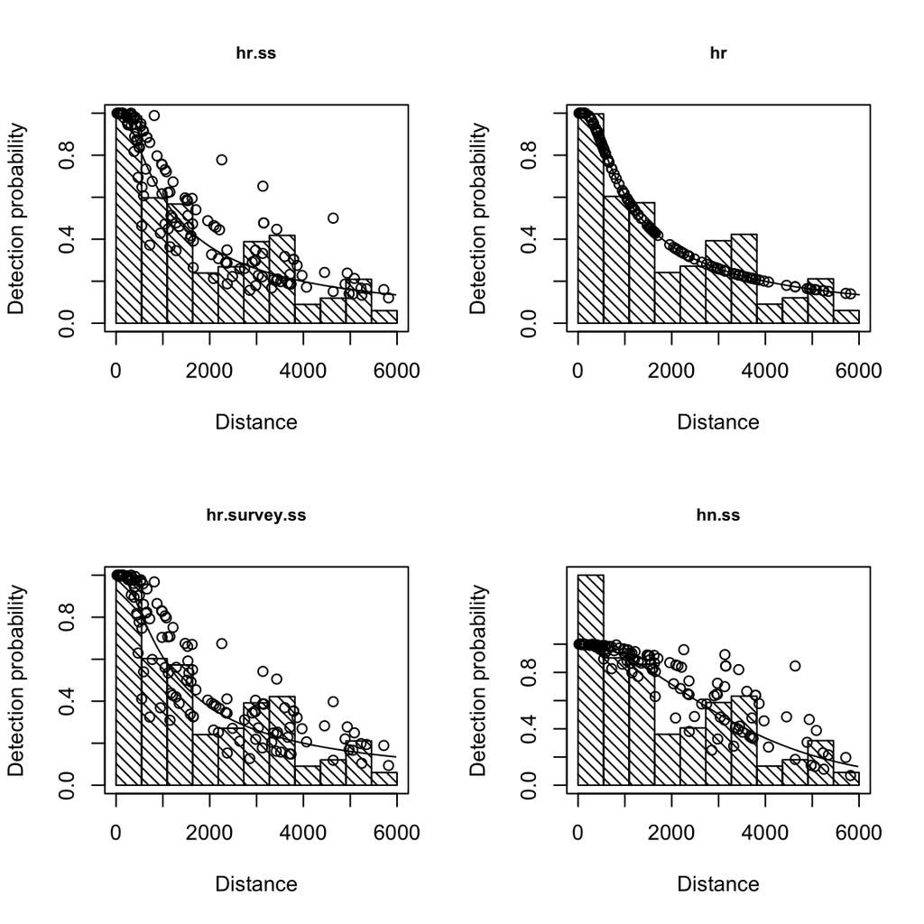

```r
par(mfrow=c(2,2))
plot(models$hr.ss, main="hr.ss")
plot(models$hr, main="hr")
plot(models$hr.survey.ss, main="hr.survey.ss")
plot(models$hn.ss, main="hn.ss")
```

and produce the corresponding quantile-quantile plots and goodness of fit test results

```r
par(mfrow=c(2,2))
ddf.gof(models$hr.ss$ddf, main="hr.ss")
```

```
##
## Goodness of fit results for ddf object
##
## Chi-square tests
##               [0,545] (545,1.09e+03] (1.09e+03,1.64e+03]
## Observed  33.00000000     20.0000000          19.0000000
## Expected  31.32360507     22.6937590          16.4840053
## Chisquare  0.08971828      0.3197503           0.3840225
##           (1.64e+03,2.18e+03] (2.18e+03,2.73e+03] (2.73e+03,3.27e+03]
## Observed             8.000000           9.0000000           13.000000
## Expected            12.761892          10.3524163            8.680087
## Chisquare            1.776822           0.1766766            2.149938
##           (3.27e+03,3.82e+03] (3.82e+03,4.36e+03] (4.36e+03,4.91e+03]
## Observed            14.000000            3.000000            4.000000
## Expected             7.456837            6.525648            5.794358
## Chisquare            5.741440            1.904821            0.555665
##           (4.91e+03,5.45e+03] (5.45e+03,6e+03]     Total
## Observed            7.0000000         2.000000 132.00000
## Expected            5.2055057         4.721887 132.00000
## Chisquare           0.6186161         1.569006  15.28648
##
## P =0.032498 with 7 degrees of freedom
##
## Distance sampling Kolmogorov-Smirnov test
## Test statistic =  0.051254  P =  0.87867
##
## Distance sampling Cramer-von Mises test(unweighted)
## Test statistic =  0.049771  P =  0.87767
```

```r
ddf.gof(models$hr$ddf, main="hr")
```

```
##
## Goodness of fit results for ddf object
##
## Chi-square tests
##               [0,545] (545,1.09e+03] (1.09e+03,1.64e+03]
## Observed  33.00000000     20.0000000          19.0000000
## Expected  31.48591783     22.9455900          16.4892751
## Chisquare  0.07280858      0.3781337           0.3822933
##           (1.64e+03,2.18e+03] (2.18e+03,2.73e+03] (2.73e+03,3.27e+03]
## Observed             8.000000           9.0000000           13.000000
## Expected            12.694336          10.2720020            8.606264
## Chisquare            1.735955           0.1575145            2.243124
##           (3.27e+03,3.82e+03] (3.82e+03,4.36e+03] (4.36e+03,4.91e+03]
## Observed            14.000000            3.000000           4.0000000
## Expected             7.394778            6.476060           5.7561940
## Chisquare            5.899969            1.865794           0.5358085
##           (4.91e+03,5.45e+03] (5.45e+03,6e+03]     Total
## Observed            7.0000000         2.000000 132.00000
## Expected            5.1772487         4.702334 132.00000
## Chisquare           0.6417351         1.552976  15.46611
##
## P =0.050691 with 8 degrees of freedom
##
## Distance sampling Kolmogorov-Smirnov test
## Test statistic =  0.049372  P =  0.90447
##
## Distance sampling Cramer-von Mises test(unweighted)
## Test statistic =  0.045352  P =  0.90383
```

```r
ddf.gof(models$hr.survey.ss$ddf, main="hr.survey.ss")
```

```
##
## Goodness of fit results for ddf object
##
## Chi-square tests
##              [0,545] (545,1.09e+03] (1.09e+03,1.64e+03]
## Observed  33.0000000     20.0000000          19.0000000
## Expected  31.0241155     22.7734980          16.6397796
## Chisquare  0.1258414      0.3377738           0.3347785
##           (1.64e+03,2.18e+03] (2.18e+03,2.73e+03] (2.73e+03,3.27e+03]
## Observed             8.000000           9.0000000           13.000000
## Expected            12.875199          10.4177610            8.708140
## Chisquare            1.845996           0.1929442            2.115269
##           (3.27e+03,3.82e+03] (3.82e+03,4.36e+03] (4.36e+03,4.91e+03]
## Observed            14.000000            3.000000           4.0000000
## Expected             7.457834            6.507207           5.7618492
## Chisquare            5.738924            1.890289           0.5387355
##           (4.91e+03,5.45e+03] (5.45e+03,6e+03]     Total
## Observed            7.0000000         2.000000 132.00000
## Expected            5.1628517         4.671765 132.00000
## Chisquare           0.6537306         1.527972  15.30225
##
## P =0.018032 with 6 degrees of freedom
##
## Distance sampling Kolmogorov-Smirnov test
## Test statistic =  0.044603  P =  0.95542
##
## Distance sampling Cramer-von Mises test(unweighted)
## Test statistic =  0.046862  P =  0.89505
```

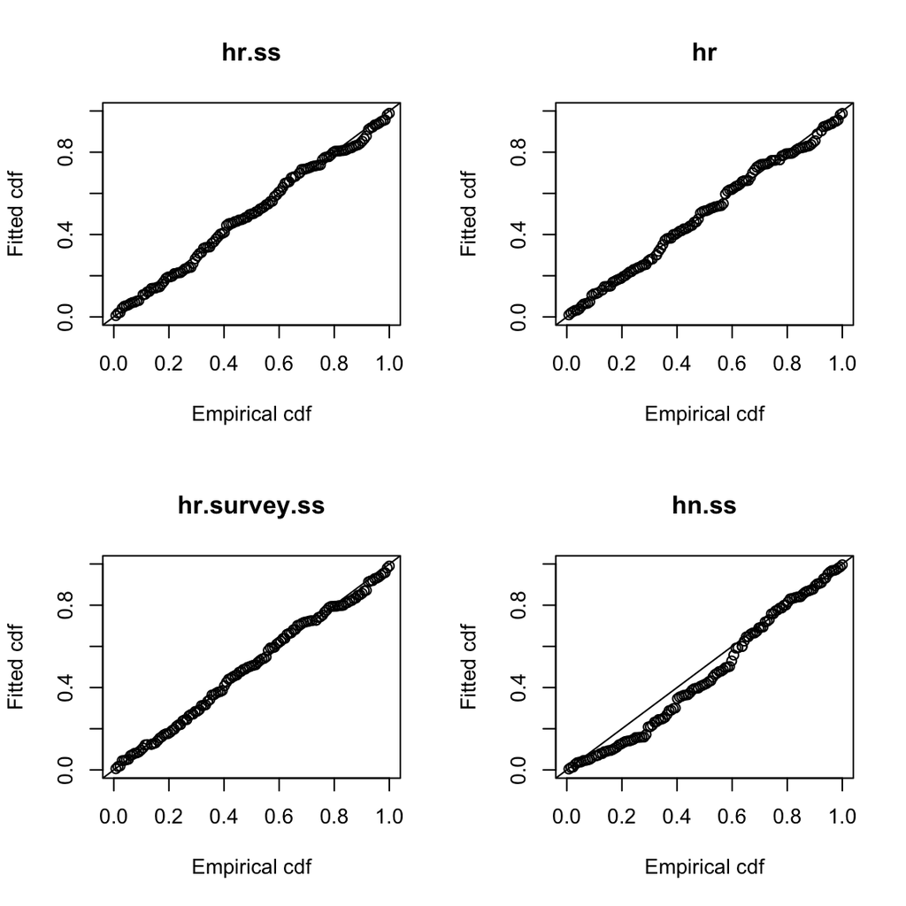

```
##
## Goodness of fit results for ddf object
##
## Chi-square tests
##             [0,545] (545,1.09e+03] (1.09e+03,1.64e+03] (1.64e+03,2.18e+03]
## Observed  33.000000    20.00000000        19.000000000            8.000000
## Expected  21.955529    20.79805129        18.766570631           16.270057
## Chisquare  5.555791     0.03062238         0.002903528            4.203664
##           (2.18e+03,2.73e+03] (2.73e+03,3.27e+03] (3.27e+03,3.82e+03]
## Observed             9.000000          13.0000000           14.000000
## Expected            13.670386          11.2069324            9.007812
## Chisquare            1.595603           0.2868842            2.766703
##           (3.82e+03,4.36e+03] (4.36e+03,4.91e+03] (4.91e+03,5.45e+03]
## Observed             3.000000           4.0000000            7.000000
## Expected             7.126130           5.5681138            4.311506
## Chisquare            2.389088           0.4416183            1.676445
##           (5.45e+03,6e+03]     Total
## Observed         2.0000000 132.00000
## Expected         3.3189113 132.00000
## Chisquare        0.5241258  19.47345
##
## P =0.012523 with 8 degrees of freedom
##
## Distance sampling Kolmogorov-Smirnov test
## Test statistic =  0.12086  P =  0.042285
##
## Distance sampling Cramer-von Mises test(unweighted)
## Test statistic =  0.40498  P =  0.070096
```

```r
ddf.gof(models$hn.ss$ddf, main="hn.ss")
```

(that was a lot of output, we can get rid of that by setting `results="hide"` in the chunk above).

## Estimating abundance

Just for fun, let’s estimate abundance from these models using a Horvtiz-Thompson-type estimator.

We know the Horvitz-Thompson estimator has the following form: $\hat{N} = \frac{A}{a} \sum_{i=1}^n \frac{s_i}{p_i}$ we can calculate each part of this equation in R:

First we need to load the effort data from the geodatabase, this is in the “Segments” table. We can then use this to build the “`sample.table`”

*Don’t worry too much about understanding this code!*

```r
# load the segment data
segs <- readOGR("Analysis.gdb", "Segments")
```

```
## NOTE: rgdal::checkCRSArgs: no proj_defs.dat in PROJ.4 shared files
```

```r
# convert to data.frame
segs <- as.data.frame(segs)

# remove unused columns
segs$Shape_Length <- NULL
segs$BeginTime <- NULL
segs$CenterTime <- NULL
segs$EndTime <- NULL
segs$FIRST_Survey <- NULL

library(plyr)

# make a copy of the segs data.frame, remove segment ID
segs2 <- segs
segs2$SegmentID <- NULL

# sum the length per transect
sample.table <- ddply(segs2, .(EffortDayID), summarize, Transect.Length=sum(Length))
# give the columns the right names
names(sample.table) <- c("Sample.Label", "Effort")
sample.table$Region.Label <- "StudyArea"
```

The total area of the study area is $A=5.285e+11 m^2$, we can use that to construct the region table, with one region in it:

```r
region.table <- data.frame(Region.Label = "StudyArea",
                           Area         = 5.285e+11)
```

Finally we can construct the observation table to link the samples to the detection function. This involves taking each distance data entry and finding the corresponding observation segment entry.

```r
# set the segment labels
segs$Sample.Label <- segs$SegmentID

# join the segment data onto the distance data
obs.table <- join(distdata, segs, by="Sample.Label")
distdata$Sample.Label <- NULL
obs.table$Sample.Label <- obs.table$EffortDayID
obs.table <- obs.table[,c("object","Sample.Label")]
obs.table$Region.Label <- "StudyArea"
```

Now we can call teh `dht` function that will estimate the abundance for us, given the tables we’ve constructed:

```r
Nhat_hr.ss <- dht(models$hr.ss$ddf, region.table, sample.table, obs.table)
Nhat_hr.ss
```

```
##
## Summary for clusters
##
## Summary statistics:
##      Region      Area  CoveredArea  Effort   n  k           ER
## 1 StudyArea 5.285e+11 113981689066 9498474 132 69 1.389697e-05
##          se.ER     cv.ER
## 1 2.701497e-06 0.1943947
##
## Abundance:
##   Label Estimate       se        cv      lcl      ucl       df
## 1 Total 1707.866 473.5064 0.2772503 998.3714 2921.565 185.4831
##
## Density:
##   Label     Estimate          se        cv          lcl          ucl
## 1 Total 3.231535e-09 8.95944e-10 0.2772503 1.889066e-09 5.528031e-09
##         df
## 1 185.4831
##
## Summary for individuals
##
## Summary statistics:
##      Region      Area  CoveredArea  Effort     n           ER        se.ER
## 1 StudyArea 5.285e+11 113981689066 9498474 238.7 2.513035e-05 5.667492e-06
##       cv.ER mean.size   se.mean
## 1 0.2255238  1.808333 0.1020928
##
## Abundance:
##   Label Estimate     se        cv      lcl      ucl       df
## 1 Total 2993.335 891.64 0.2978751 1683.154 5323.372 163.6538
##
## Density:
##   Label     Estimate           se        cv          lcl          ucl
## 1 Total 5.663832e-09 1.687115e-09 0.2978751 3.184776e-09 1.007261e-08
##         df
## 1 163.6538
##
## Expected cluster size
##   Region Expected.S se.Expected.S cv.Expected.S
## 1  Total   1.752675     0.1381592    0.07882757
## 2  Total   1.752675     0.1381592    0.07882757
```

We can also use the `hn.ss` model to get an abundance estimate for that model too:

```r
Nhat_hn.ss <- dht(models$hn.ss$ddf, region.table, sample.table, obs.table)
Nhat_hn.ss
```

```
##
## Summary for clusters
##
## Summary statistics:
##      Region      Area  CoveredArea  Effort   n  k           ER
## 1 StudyArea 5.285e+11 113981689066 9498474 132 69 1.389697e-05
##          se.ER     cv.ER
## 1 2.701497e-06 0.1943947
##
## Abundance:
##   Label Estimate       se        cv     lcl      ucl       df
## 1 Total 1130.211 226.3852 0.2003034 762.032 1676.278 87.70608
##
## Density:
##   Label     Estimate           se        cv          lcl          ucl
## 1 Total 2.138526e-09 4.283541e-10 0.2003034 1.441877e-09 3.171765e-09
##         df
## 1 87.70608
##
## Summary for individuals
##
## Summary statistics:
##      Region      Area  CoveredArea  Effort     n           ER        se.ER
## 1 StudyArea 5.285e+11 113981689066 9498474 238.7 2.513035e-05 5.667492e-06
##       cv.ER mean.size   se.mean
## 1 0.2255238  1.808333 0.1020928
##
## Abundance:
##   Label Estimate       se        cv      lcl      ucl       df
## 1 Total 1982.134 461.3902 0.2327745 1254.929 3130.738 80.50493
##
## Density:
##   Label     Estimate           se        cv          lcl          ucl
## 1 Total 3.750489e-09 8.730184e-10 0.2327745 2.374511e-09 5.923817e-09
##         df
## 1 80.50493
##
## Expected cluster size
##   Region Expected.S se.Expected.S cv.Expected.S
## 1  Total   1.753773     0.1383593    0.07889239
## 2  Total   1.753773     0.1383593    0.07889239
```

As we can see, there is a definite difference between the abundance estimates for these two models.

### Accounting for perception bias

From Palka (2006), we think that observations on the track line were such that $g(0)=0.46$, we can apply that correction to our abundance estimate (in a very primitive way):

```r
Nhat_hr.ss$individuals$N$Estimate/0.46
```

```
## Nhat.by.sample$Region.Label: StudyArea
## [1] 6507.25
```

```r
Nhat_hn.ss$individuals$N$Estimate/0.46
```

```
## Nhat.by.sample$Region.Label: StudyArea
## [1] 4308.986
```

This kind of correction works fine when we have a single number to adjust by, in general we’d like to model the perception bias using “mark-recapture distance sampling” techniques.

## Save model objects

Let’s save our top four models (`hr.ss`, `hr`, `hr.survey.ss` and `hn.ss`) in the RData format, so we can load them up later on.

```r
df_hr_ss <- models$hr.ss
df_hr_survey_ss <- models$hr.survey.ss
df_hr <- models$hr
df_hn_ss <- models$hn.ss
save(df_hr_ss, df_hr_survey_ss, df_hr, df_hn_ss,
     distdata, region.table, sample.table, obs.table,
     file="df-models.RData")
```

## References

Palka, D. (2006). Summer Abundance Estimates of Cetaceans in US North Atlantic Navy Operating Areas. Northeast Fisheries Science Center Reference Document 06-03. [Available online here](http://www.nefsc.noaa.gov/nefsc/publications/crd/crd1229/crd1229.pdf)